# PREPARED BY POWELL A. NDLOVU

## Bosherstone Lakes Data Analysis Jupyter Note book

# Load our Libraries

```python
import pandas as pd
import numpy as np
import matplotlib.pyplot as plt
from pathlib import Path
from datetime import datetime
import seaborn as sns
import pandas as pd
import numpy as np
import plotly.express as px
import plotly.graph_objects as go
from plotly.subplots import make_subplots
import warnings
warnings.filterwarnings('ignore')
```

## Load data set

```python
df = pd.read_csv('data.csv', encoding='ISO-8859-1')
```

```python
df.head()
```

|  | Sampling Date | Max of RESULT | Sampling point | Parameter |
| --- | --- | --- | --- | --- |
| 0 | 2/15/2016 | 12.7077 | Central_Arm | Oxygen_Dissolved_O2 |
| 1 | 3/2/2016 | 13.0000 | Central_Arm | Oxygen_Dissolved_O2 |
| 2 | 4/13/2016 | 11.3000 | Central_Arm | Oxygen_Dissolved_O2 |
| 3 | 5/13/2016 | 11.1471 | Central_Arm | Oxygen_Dissolved_O2 |
| 4 | 6/2/2016 | 17.7365 | Central_Arm | Oxygen_Dissolved_O2 |

## Now lets change our column names to more meaningful names

```python
df.head()
```

|  | Sampling Date | Max of RESULT | Sampling point | Parameter |
| --- | --- | --- | --- | --- |
| 0 | 2/15/2016 | 12.7077 | Central_Arm | Oxygen_Dissolved_O2 |
| 1 | 3/2/2016 | 13.0000 | Central_Arm | Oxygen_Dissolved_O2 |
| 2 | 4/13/2016 | 11.3000 | Central_Arm | Oxygen_Dissolved_O2 |
| 3 | 5/13/2016 | 11.1471 | Central_Arm | Oxygen_Dissolved_O2 |
| 4 | 6/2/2016 | 17.7365 | Central_Arm | Oxygen_Dissolved_O2 |

### We want to clean and unpivot this data set so that we have all our elements as columns

### Data Information

```python
df.info()
```

```
<class 'pandas.core.frame.DataFrame'>
RangeIndex: 10331 entries, 0 to 10330
Data columns (total 4 columns):
 #   Column          Non-Null Count  Dtype
---  ------          --------------  -----
 0   Sampling Date   10331 non-null  object
 1   Max of RESULT   10329 non-null  float64
 2   Sampling point  10331 non-null  object
 3   Parameter       10331 non-null  object
dtypes: float64(1), object(3)
memory usage: 323.0+ KB
```

### Lets check the missing values in our data set

```python
df.isnull().sum()
```

```
Sampling Date     0
Max of RESULT     2
Sampling point    0
Parameter         0
dtype: int64
```

### Clean column names

```python
df.columns = df.columns.str.strip().str.replace(" ", "_")
```

```python
df.columns
```

```
Index(['Sampling_Date', 'Max_of_RESULT', 'Sampling_point', 'Parameter'], dtype='object')
```

## Pivot the dataset: parameters become individual columns

```python
df_wide = df.pivot_table(index=["Sampling_Date", "Sampling_point"],
                         columns="Parameter",
                         values="Max_of_RESULT").reset_index()
```

#### Now we have a new data set df_wide an unpivoted table

## Flatten multi-index columns if any

```python
df_wide.columns.name = None
df_wide.columns = [str(col) for col in df_wide.columns]
```

```python
df_wide.head()
```

|  | Sampling_Date | Sampling_point | Conductivity_At_20c | Nitrate_As_N | Oxygen_Dissolved_O2 | Phosphorous | Temperature | pH |
| --- | --- | --- | --- | --- | --- | --- | --- | --- |
| 0 | 1/10/1984 | Bosherston_From_MerrionStream_Under_OneArchBridge | 638.0 | NaN | NaN | 0.10 | 9.8 | 7.8 |
| 1 | 1/10/1984 | Broadwalk | 379.0 | NaN | NaN | 0.14 | 9.7 | 7.8 |
| 2 | 1/10/1984 | Central_Lake_Causeway | 575.0 | NaN | NaN | 0.02 | 6.0 | 8.1 |
| 3 | 1/10/1984 | Central_Lake_East_Side | 518.0 | NaN | NaN | 0.08 | 5.8 | 8.1 |
| 4 | 1/10/1984 | Lower_Eastern_Arm_Near_Grassy_Bridge | 502.0 | NaN | NaN | 0.08 | 6.2 | 8.0 |

#### Now we want to check the percentage of missing values and drop higher percentage and leave the one with lower missing percentag

```python
# Calculate % of missing values per column
na_percent = df_wide.isna().mean() * 100

# Display nicely sorted descending
na_percent = na_percent.sort_values(ascending=False)

print(na_percent)
```

```
Oxygen_Dissolved_O2    88.449940
Nitrate_As_N           86.218335
Phosphorous            59.107358
Conductivity_At_20c    37.846803
Temperature            23.100121
pH                     11.248492
Sampling_Date           0.000000
Sampling_point          0.000000
dtype: float64
```

##### We are going to drop Oxygen_Dissolved_O2 88%, Nitrate_As_N 86% and Phosphorous 59% missing values

## Lets Drop the above columns

```python
cols_to_drop = ["Oxygen_Dissolved_O2", "Nitrate_As_N", "Phosphorous"]
```

```python
df_wide = df_wide.drop(columns=[c for c in cols_to_drop if c in df_wide.columns])
```

```python
df_wide.head()
```

|  | Sampling_Date | Sampling_point | Conductivity_At_20c | Temperature | pH |
| --- | --- | --- | --- | --- | --- |
| 0 | 1/10/1984 | Bosherston_From_MerrionStream_Under_OneArchBridge | 638.0 | 9.8 | 7.8 |
| 1 | 1/10/1984 | Broadwalk | 379.0 | 9.7 | 7.8 |
| 2 | 1/10/1984 | Central_Lake_Causeway | 575.0 | 6.0 | 8.1 |
| 3 | 1/10/1984 | Central_Lake_East_Side | 518.0 | 5.8 | 8.1 |
| 4 | 1/10/1984 | Lower_Eastern_Arm_Near_Grassy_Bridge | 502.0 | 6.2 | 8.0 |

###### NOW WE ARE LEFT WITH OUR DATA SET Conductivity, Temperature and pH

```python
df_wide.info()
```

```
<class 'pandas.core.frame.DataFrame'>
RangeIndex: 3316 entries, 0 to 3315
Data columns (total 5 columns):
 #   Column               Non-Null Count  Dtype
---  ------               --------------  -----
 0   Sampling_Date        3316 non-null   object
 1   Sampling_point       3316 non-null   object
 2   Conductivity_At_20c  2061 non-null   float64
 3   Temperature          2550 non-null   float64
 4   pH                   2943 non-null   float64
dtypes: float64(3), object(2)
memory usage: 129.7+ KB
```

#### NOW WE WANT TO CONSTRUCT MONTH COLUMNS AND CHANGE OUR DATE FORMAT TO THE FORMAT RECOGNISABLE BY PYTHON

```python
df_wide["Sampling_Date"] = pd.to_datetime(df_wide["Sampling_Date"], dayfirst=True, errors="coerce")
```

```python
df_wide["Month"] = df_wide["Sampling_Date"].dt.month
```

```python
df_wide.head()
```

|  | Sampling_Date | Sampling_point | Conductivity_At_20c | Temperature | pH | Month |
| --- | --- | --- | --- | --- | --- | --- |
| 0 | 1984-10-01 | Bosherston_From_MerrionStream_Under_OneArchBridge | 638.0 | 9.8 | 7.8 | 10.0 |
| 1 | 1984-10-01 | Broadwalk | 379.0 | 9.7 | 7.8 | 10.0 |
| 2 | 1984-10-01 | Central_Lake_Causeway | 575.0 | 6.0 | 8.1 | 10.0 |
| 3 | 1984-10-01 | Central_Lake_East_Side | 518.0 | 5.8 | 8.1 | 10.0 |
| 4 | 1984-10-01 | Lower_Eastern_Arm_Near_Grassy_Bridge | 502.0 | 6.2 | 8.0 | 10.0 |

### Lets add the Month Name

```python
df_wide["Month_Name"] = df_wide["Sampling_Date"].dt.strftime("%B")
```

```python
df_wide[["Sampling_Date", "Month", "Month_Name"]].head()
```

|  | Sampling_Date | Month | Month_Name |
| --- | --- | --- | --- |
| 0 | 1984-10-01 | 10.0 | October |
| 1 | 1984-10-01 | 10.0 | October |
| 2 | 1984-10-01 | 10.0 | October |
| 3 | 1984-10-01 | 10.0 | October |
| 4 | 1984-10-01 | 10.0 | October |

### Lets Create the season column based on the UK Seasons

```python
df_wide["Season"] = np.where(df_wide["Month"].isin([12, 1, 2]), "Winter",
                     np.where(df_wide["Month"].isin([3, 4, 5]), "Spring",
                     np.where(df_wide["Month"].isin([6, 7, 8]), "Summer",
                     "Autumn")))
```

```python
df_wide.head()
```

|  | Sampling_Date | Sampling_point | Conductivity_At_20c | Temperature | pH | Month | Month_Name | Season |
| --- | --- | --- | --- | --- | --- | --- | --- | --- |
| 0 | 1984-10-01 | Bosherston_From_MerrionStream_Under_OneArchBridge | 638.0 | 9.8 | 7.8 | 10.0 | October | Autumn |
| 1 | 1984-10-01 | Broadwalk | 379.0 | 9.7 | 7.8 | 10.0 | October | Autumn |
| 2 | 1984-10-01 | Central_Lake_Causeway | 575.0 | 6.0 | 8.1 | 10.0 | October | Autumn |
| 3 | 1984-10-01 | Central_Lake_East_Side | 518.0 | 5.8 | 8.1 | 10.0 | October | Autumn |
| 4 | 1984-10-01 | Lower_Eastern_Arm_Near_Grassy_Bridge | 502.0 | 6.2 | 8.0 | 10.0 | October | Autumn |

#### Create the year column

```python
df_wide["Year"] = df_wide["Sampling_Date"].dt.year
```

```python
df_wide[["Sampling_Date", "Year", 'Month', 'Month_Name','Season']].head()
```

|  | Sampling_Date | Year | Month | Month_Name | Season |
| --- | --- | --- | --- | --- | --- |
| 0 | 1984-10-01 | 1984.0 | 10.0 | October | Autumn |
| 1 | 1984-10-01 | 1984.0 | 10.0 | October | Autumn |
| 2 | 1984-10-01 | 1984.0 | 10.0 | October | Autumn |
| 3 | 1984-10-01 | 1984.0 | 10.0 | October | Autumn |
| 4 | 1984-10-01 | 1984.0 | 10.0 | October | Autumn |

### Our Data set is now ready for analysis lets view it and lets see

```python
df_wide.head()
```

|  | Sampling_Date | Sampling_point | Conductivity_At_20c | Temperature | pH | Month | Month_Name | Season | Year |
| --- | --- | --- | --- | --- | --- | --- | --- | --- | --- |
| 0 | 1984-10-01 | Bosherston_From_MerrionStream_Under_OneArchBridge | 638.0 | 9.8 | 7.8 | 10.0 | October | Autumn | 1984.0 |
| 1 | 1984-10-01 | Broadwalk | 379.0 | 9.7 | 7.8 | 10.0 | October | Autumn | 1984.0 |
| 2 | 1984-10-01 | Central_Lake_Causeway | 575.0 | 6.0 | 8.1 | 10.0 | October | Autumn | 1984.0 |
| 3 | 1984-10-01 | Central_Lake_East_Side | 518.0 | 5.8 | 8.1 | 10.0 | October | Autumn | 1984.0 |
| 4 | 1984-10-01 | Lower_Eastern_Arm_Near_Grassy_Bridge | 502.0 | 6.2 | 8.0 | 10.0 | October | Autumn | 1984.0 |

### Lets save it as a csv file and re load it for analysis

```python
df_wide.to_csv('df_wide_cleand.csv')
```

## Lets check missing valus and percentage of missing values

```python
df = pd.read_csv('df_wide_cleaned.csv', encoding='ISO-8859-1')
```

```python
df_wide.isnull().sum()
```

```
Sampling_Date          2333
Sampling_point            0
Conductivity_At_20c    1255
Temperature             766
pH                      373
Month                  2333
Month_Name             2333
Season                    0
Year                   2333
dtype: int64
```

```python
df.head()
```

|  | Sampling_Date | Sampling_point | Conductivity_At_20c | Temperature | pH | Month_Name | Year | Month | Season |
| --- | --- | --- | --- | --- | --- | --- | --- | --- | --- |
| 0 | 1977-07-26 | Central_Lake_Causeway | 360.0 | 16.0 | 7.9 | July | 1977 | 7 | Summer |
| 1 | 1977-07-26 | Central_Lake_East_Side | 300.0 | 16.5 | 8.9 | July | 1977 | 7 | Summer |
| 2 | 1977-07-26 | Lower_Eastern_Arm_Near_Grassy_Bridge | 380.0 | 18.0 | 8.4 | July | 1977 | 7 | Summer |
| 3 | 1977-07-26 | Survey_Point_Q | 600.0 | 12.0 | 7.7 | July | 1977 | 7 | Summer |
| 4 | 1977-07-26 | Upper_EasternArm_Near_Eight_Arch_Bridge | 390.0 | 18.5 | 8.2 | July | 1977 | 7 | Summer |

## Data Cleaning and Manupulation

### Lets covert our Sample date to date time format undrstood by python

```python
df['Sampling_Date'] = pd.to_datetime(df['Sampling_Date'], errors='coerce')
```

```python
df.info()
```

```
<class 'pandas.core.frame.DataFrame'>
RangeIndex: 3316 entries, 0 to 3315
Data columns (total 9 columns):
 #   Column               Non-Null Count  Dtype
---  ------               --------------  -----
 0   Sampling_Date        3316 non-null   datetime64[ns]
 1   Sampling_point       3316 non-null   object
 2   Conductivity_At_20c  2061 non-null   float64
 3   Temperature          2550 non-null   float64
 4   pH                   2943 non-null   float64
 5   Month_Name           3316 non-null   object
 6   Year                 3316 non-null   int64
 7   Month                3316 non-null   int64
 8   Season               3316 non-null   object
dtypes: datetime64[ns](1), float64(3), int64(2), object(3)
memory usage: 233.3+ KB
```

##### Python now recognises smple time as date time which is important for analysing yearly, seasonal variatons

#### We want to allocate the abve Sampling point to Eastern_Arm, Western_Arm, Center_Arm and our target inflow (Upper_Westerm_Arm_Spring_Infw) to Western Arm_Spring_Inflow

```python
df['Sampling_point'].unique()
```

```
array(['Central_Lake_Causeway', 'Central_Lake_East_Side',
       'Lower_Eastern_Arm_Near_Grassy_Bridge', 'Survey_Point_Q',
       'Upper_EasternArm_Near_Eight_Arch_Bridge',
       'Upper_Westerm_Arm_Spring_Infw', 'Broadwalk',
       'West_Arm_WestSide_Halfway_Up_The_Arm',
       'Bosherston_From_MerrionStream_Under_OneArchBridge', 'Central_Arm',
       'Lower_Easetern_Arm_Near_Grassy_Bridge'], dtype=object)
```

##### 1. Rename the column Sampling point as Ponds

```python
# 1. Rename the column
df = df.rename(columns={'Sampling_point': 'Ponds', 'Conductivity_At_20c': 'Conductivity'})
```

```python
df.head()
```

|  | Sampling_Date | Ponds | Conductivity | Temperature | pH | Month_Name | Year | Month | Season |
| --- | --- | --- | --- | --- | --- | --- | --- | --- | --- |
| 0 | 1977-07-26 | Central_Lake_Causeway | 360.0 | 16.0 | 7.9 | July | 1977 | 7 | Summer |
| 1 | 1977-07-26 | Central_Lake_East_Side | 300.0 | 16.5 | 8.9 | July | 1977 | 7 | Summer |
| 2 | 1977-07-26 | Lower_Eastern_Arm_Near_Grassy_Bridge | 380.0 | 18.0 | 8.4 | July | 1977 | 7 | Summer |
| 3 | 1977-07-26 | Survey_Point_Q | 600.0 | 12.0 | 7.7 | July | 1977 | 7 | Summer |
| 4 | 1977-07-26 | Upper_EasternArm_Near_Eight_Arch_Bridge | 390.0 | 18.5 | 8.2 | July | 1977 | 7 | Summer |

```python
df['Ponds'].unique()
```

```
array(['Central_Lake_Causeway', 'Central_Lake_East_Side',
       'Lower_Eastern_Arm_Near_Grassy_Bridge', 'Survey_Point_Q',
       'Upper_EasternArm_Near_Eight_Arch_Bridge',
       'Upper_Westerm_Arm_Spring_Infw', 'Broadwalk',
       'West_Arm_WestSide_Halfway_Up_The_Arm',
       'Bosherston_From_MerrionStream_Under_OneArchBridge', 'Central_Arm',
       'Lower_Easetern_Arm_Near_Grassy_Bridge'], dtype=object)
```

```python
df['Ponds'] = df['Ponds'].replace(
    ['West_Arm_WestSide_Halfway_Up_The_Arm','Bosherston_From_MerrionStream_Under_OneArchBridge'],
     'Western_Arm'
) # Here we allocated the two under Western Arm
```

```python
df['Ponds'] = df['Ponds'].replace(
    ['Lower_Eastern_Arm_Near_Grassy_Bridge','Broadwalk','Upper_EasternArm_Near_Eight_Arch_Bridge','Lower_Easetern_Arm_Near_Grassy_Bridge'],
     'Eastern_Arm'
) #Here we have allocated the 3 under the Eastern arm
```

```python
df['Ponds'] = df['Ponds'].replace(
    ['Central_Lake_Causeway','Central_Lake_East_Side','Central_Arm'],
     'Central_Arm'
) #Here we have allocated the 3 under the Central arm
```

```python
df['Ponds'] = df['Ponds'].replace(
    ['Upper_Westerm_Arm_Spring_Infw'],
     'Western_Arm_Spring_Inflow'
) #Here we have allocated our target inflow stream as Western_Arm_Spring_Inflow
```

#### Now lets check how we have replaced our observations under Ponds column

```python
df['Ponds'].unique()
```

```
array(['Central_Arm', 'Eastern_Arm', 'Survey_Point_Q',
       'Western_Arm_Spring_Inflow', 'Western_Arm'], dtype=object)
```

#### One more poit letf Survey Point Q....Lets check if i has much data

```python
df[df['Ponds'] == 'Survey_Point_Q'].shape
```

```
(36, 9)
```

### It has only 36 points hence we will remove it from the data set using drop column

```python
df = df.drop(df[df['Ponds'] == 'Survey_Point_Q'].index)
```

##### We have droped the Survey Point Q

### Now lets save our data as csv file so that we can access it any time for furthere analysis

```python
df.to_csv("pond_data_saved.csv", index=False)
```

## NOW WE ARE DONE WE DATA ENGINEERING AND MANUPULATION WE NOW GO TO VISUALISATION AND ANALSYIS

# Lets re load our saved data set for further analysis

```python
df = pd.read_csv('pond_data.csv')
```

```python
df.head()
```

|  | Sampling_Date | Ponds | Conductivity | Temperature | pH | Month_Name | Year | Month | Season |
| --- | --- | --- | --- | --- | --- | --- | --- | --- | --- |
| 0 | 7/26/1977 | Central_Arm | 360.0 | 16.0 | 7.9 | July | 1977 | 7 | Summer |
| 1 | 7/26/1977 | Central_Arm | 300.0 | 16.5 | 8.9 | July | 1977 | 7 | Summer |
| 2 | 7/26/1977 | Eastern_Arm | 380.0 | 18.0 | 8.4 | July | 1977 | 7 | Summer |
| 3 | 7/26/1977 | Eastern_Arm | 390.0 | 18.5 | 8.2 | July | 1977 | 7 | Summer |
| 4 | 7/26/1977 | Western_Arm_Spring_Inflow | 430.0 | 15.0 | 6.9 | July | 1977 | 7 | Summer |

# Data Visualization

### Seasonal Variations

```python
# Group by Season and Ponds to get mean values
season_group = df.groupby(["Season", "Ponds"]).mean(numeric_only=True).reset_index()
```

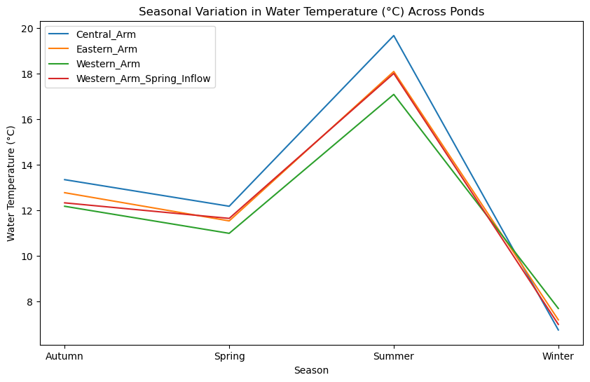

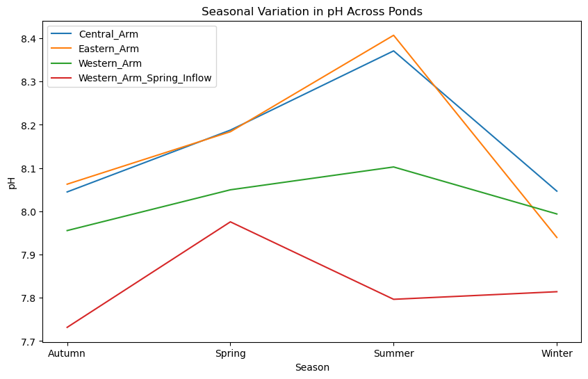

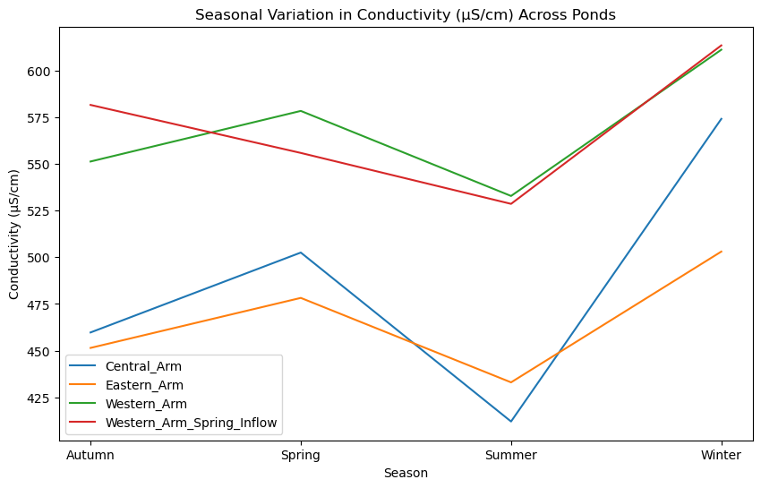

```python
# Function to plot each variable
def plot_seasonal(variable, ylabel):
    plt.figure(figsize=(10,6))

    for pond in season_group["Ponds"].unique():
        pond_data = season_group[season_group["Ponds"] == pond]
        plt.plot(pond_data["Season"], pond_data[variable], label=pond)

    plt.xlabel("Season")
    plt.ylabel(ylabel)
    plt.title(f"Seasonal Variation in {ylabel} Across Ponds")
    plt.legend()
    plt.show()

# Plot Temperature
plot_seasonal("Temperature", "Water Temperature (°C)")

# Plot pH
plot_seasonal("pH", "pH")

# Plot Conductivity
plot_seasonal("Conductivity", "Conductivity (µS/cm)")
```

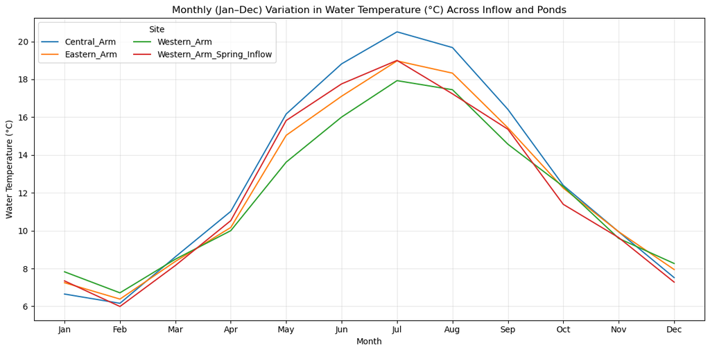

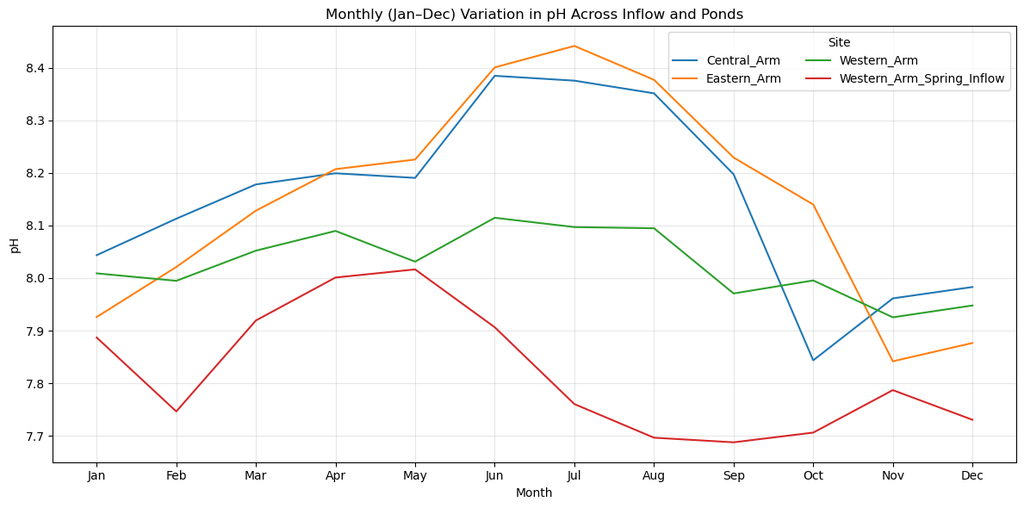

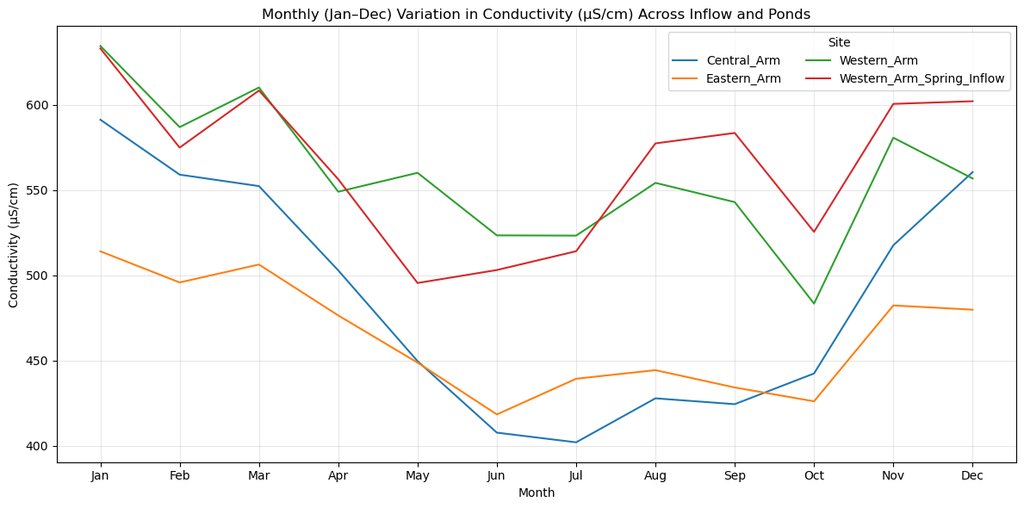

|  | Month | Month_Label | Ponds | Temperature | pH | Conductivity |
| --- | --- | --- | --- | --- | --- | --- |
| 0 | 1 | Jan | Central_Arm | 6.649167 | 8.043478 | 591.159756 |
| 1 | 1 | Jan | Eastern_Arm | 7.249070 | 7.925979 | 513.970833 |
| 2 | 1 | Jan | Western_Arm | 7.825400 | 8.008947 | 634.428571 |
| 3 | 1 | Jan | Western_Arm_Spring_Inflow | 7.344444 | 7.886970 | 632.958333 |
| 4 | 2 | Feb | Central_Arm | 6.160606 | 8.112821 | 558.944444 |
| 5 | 2 | Feb | Eastern_Arm | 6.383333 | 8.021042 | 495.716129 |
| 6 | 2 | Feb | Western_Arm | 6.714211 | 7.994762 | 586.809091 |
| 7 | 2 | Feb | Western_Arm_Spring_Inflow | 5.992308 | 7.746471 | 574.800000 |
| 11 | 3 | Mar | Western_Arm_Spring_Inflow | 8.160000 | 7.919355 | 608.304348 |
| 10 | 3 | Mar | Western_Arm | 8.492708 | 8.052115 | 610.055263 |
| 8 | 3 | Mar | Central_Arm | 8.617812 | 8.177973 | 552.223529 |
| 9 | 3 | Mar | Eastern_Arm | 8.375172 | 8.128144 | 506.230667 |

```python
import pandas as pd
import matplotlib.pyplot as plt
import calendar
# Ensure numeric columns
for col in ["Temperature", "pH", "Conductivity"]:
    df[col] = pd.to_numeric(df[col], errors="coerce")

# Month ordering and labels
month_order = list(range(1, 13))
month_labels = [calendar.month_abbr[m] for m in month_order]

# Compute monthly climatology (mean across all years) per pond
monthly = (
    df.groupby(["Month", "Ponds"], as_index=False)
      .mean(numeric_only=True)
      .sort_values("Month")
)

# Helper to plot
def plot_monthly(variable, ylabel, outfile):
    plt.figure(figsize=(12,6))
    for pond in monthly["Ponds"].unique():
        sub = monthly[monthly["Ponds"] == pond]
        # Align by month order
        sub = sub.set_index("Month").reindex(month_order).reset_index()
        plt.plot(sub["Month"], sub[variable], label=pond)
    plt.xticks(month_order, month_labels, rotation=0)
    plt.xlabel("Month")
    plt.ylabel(ylabel)
    plt.title(f"Monthly (Jan–Dec) Variation in {ylabel} Across Inflow and Ponds")
    plt.legend(title="Site", ncol=2)
    plt.grid(True, alpha=0.3)
    plt.tight_layout()
    plt.savefig(outfile, dpi=200, bbox_inches="tight")
    plt.show()

# Create three plots and save
plot_monthly("Temperature", "Water Temperature (°C)", "C:/Users/User/Desktop/Assignment_1/Nutrients_Analysis/monthly_temperature.png")
plot_monthly("pH", "pH", "C:/Users/User/Desktop/Assignment_1/Nutrients_Analysis/monthly_pH.png")
plot_monthly("Conductivity", "Conductivity (µS/cm)", "C:/Users/User/Desktop/Assignment_1/Nutrients_Analysis/monthly_conductivity.png")

# Also export the monthly means table for reference
monthly_out = monthly.copy()
monthly_out["Month_Label"] = monthly_out["Month"].map({i: calendar.month_abbr[i] for i in month_order})
monthly_out = monthly_out[["Month", "Month_Label", "Ponds", "Temperature", "pH", "Conductivity"]]
monthly_out.to_csv("C:/Users/User/Desktop/Assignment_1/Nutrients_Analysis/monthly_means_by_pond.csv", index=False)
monthly_out.head(12)
```

### Long Term Variation Over the Years

```python
# Ensure numerical
df = df.dropna(subset=["Temperature", "pH", "Conductivity"])
```

```python
# Group by Year and Ponds (averaging seasonal data to get annual trend per pond)
annual = df.groupby(["Year", "Ponds"]).mean(numeric_only=True).reset_index()
```

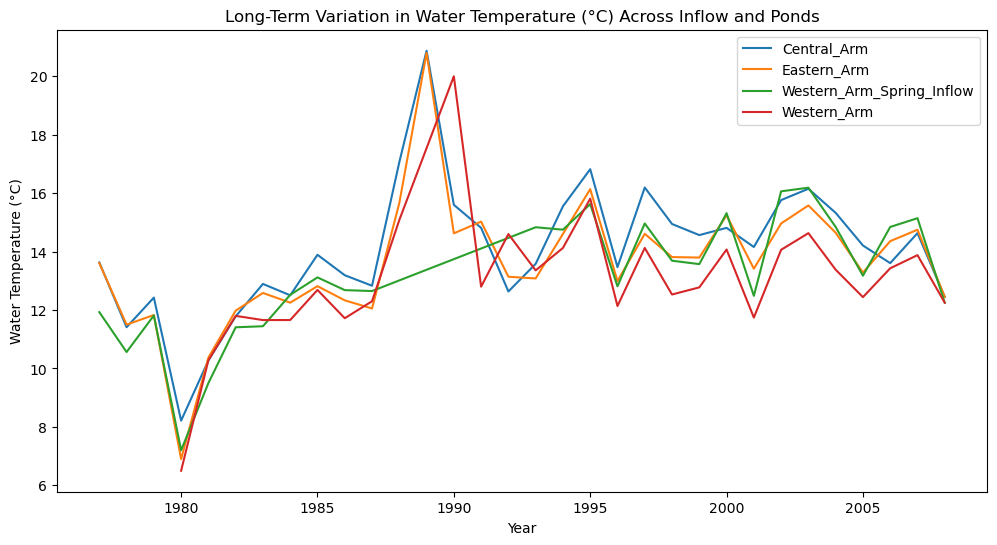

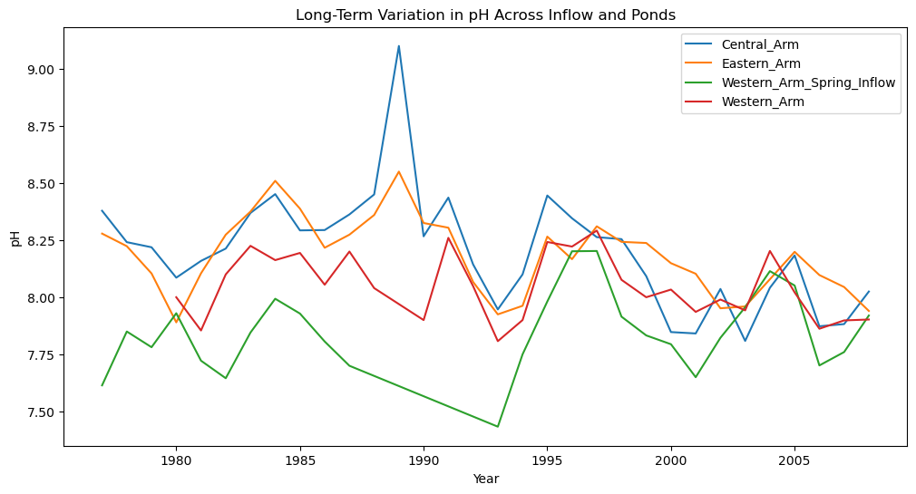

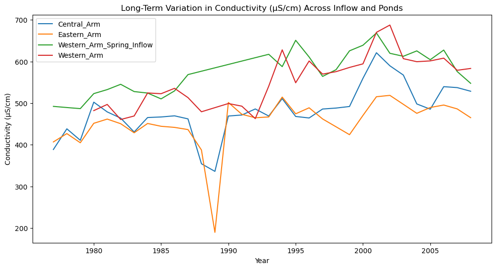

```python
# Function to plot long-term trends
def plot_longterm(variable, ylabel):
    plt.figure(figsize=(12,6))

    for pond in annual["Ponds"].unique():
        pond_data = annual[annual["Ponds"] == pond]
        plt.plot(pond_data["Year"], pond_data[variable], label=pond)

    plt.xlabel("Year")
    plt.ylabel(ylabel)
    plt.title(f"Long-Term Variation in {ylabel} Across Inflow and Ponds")
    plt.legend()
    plt.show()

# Plot Temperature across years
plot_longterm("Temperature", "Water Temperature (°C)")

# Plot pH across years
plot_longterm("pH", "pH")

# Plot Conductivity across years
plot_longterm("Conductivity", "Conductivity (µS/cm)")
```

### Kruskal Wallis to show Significance Difference between the Ponds and our target Western Spring Inflow

```python
import pandas as pd
import matplotlib.pyplot as plt
from scipy.stats import kruskal
```

```python
# Ensure numeric
for col in ["Temperature", "pH", "Conductivity"]:
    df[col] = pd.to_numeric(df[col], errors="coerce")

# List ponds
ponds = df["Ponds"].unique()

results = {}

for variable in ["Temperature", "pH", "Conductivity"]:
    groups = [df[df["Ponds"] == pond][variable].dropna() for pond in ponds]
    stat, p = kruskal(*groups)
    results[variable] = {"Statistic": stat, "p-value": p}

results
```

```
{'Temperature': {'Statistic': 5.04283109445199, 'p-value': 0.1686875734790815},
 'pH': {'Statistic': 121.68028807708366, 'p-value': 3.3538025859681413e-26},
 'Conductivity': {'Statistic': 334.2315302666763,
  'p-value': 3.870817840903634e-72}}
```

### Lets Visualize our Results

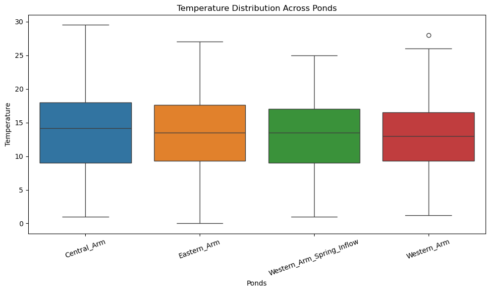

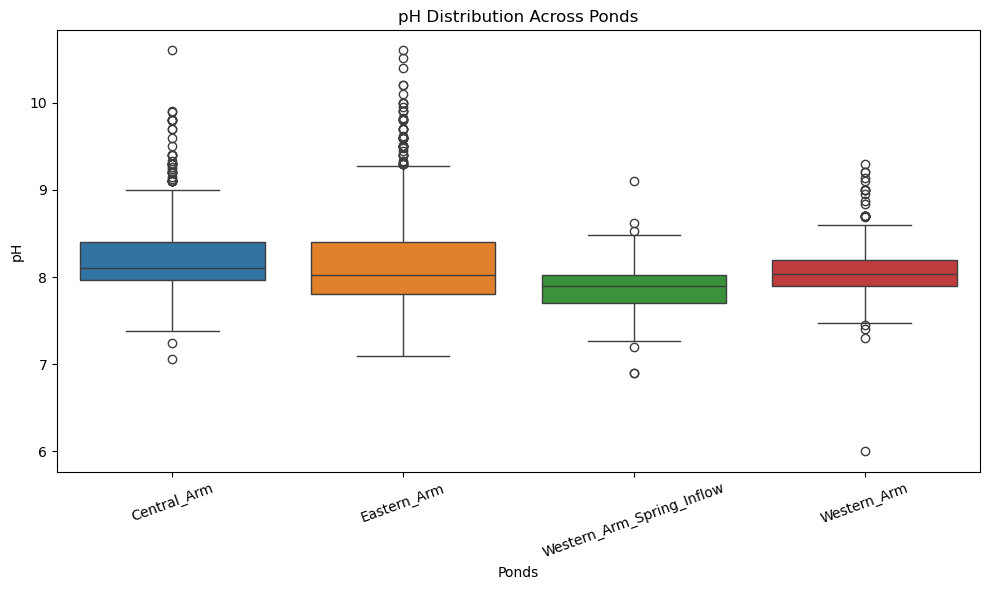

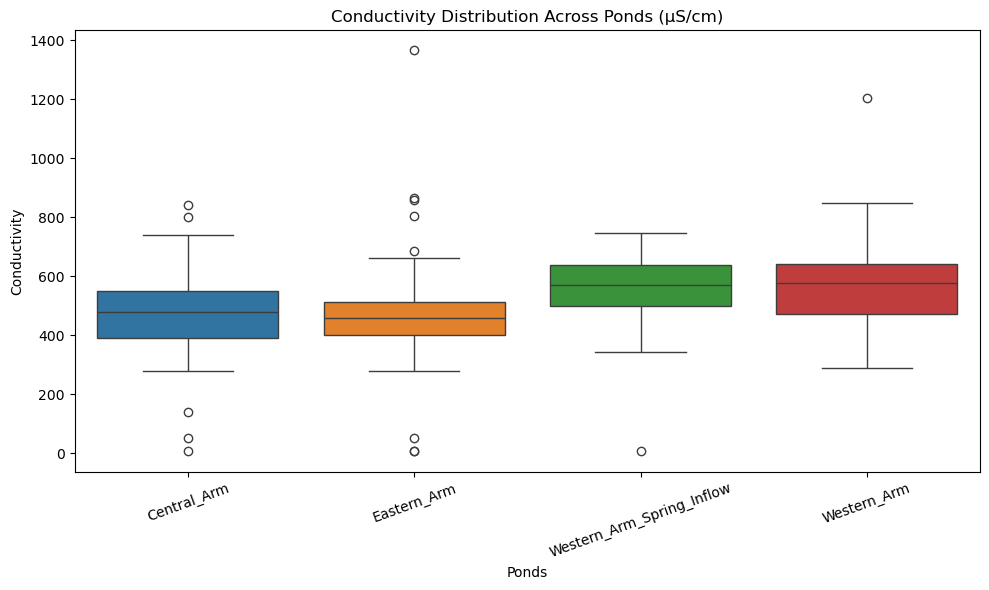

```python
import seaborn as sns

# Boxplots
plt.figure(figsize=(10,6))
sns.boxplot(data=df, x="Ponds", y="Temperature" ,hue='Ponds')
plt.title("Temperature Distribution Across Ponds")
plt.xticks(rotation=20)
plt.tight_layout()
plt.savefig("C:/Users/User/Desktop/Assignment_1/Nutrients_Analysis/temperature_boxplot.png", dpi=300)
plt.show()

plt.figure(figsize=(10,6))
sns.boxplot(data=df, x="Ponds", y="pH",hue='Ponds')
plt.title("pH Distribution Across Ponds")
plt.xticks(rotation=20)
plt.tight_layout()
plt.savefig("C:/Users/User/Desktop/Assignment_1/Nutrients_Analysis/pH_boxplot.png", dpi=300)
plt.show()

plt.figure(figsize=(10,6))
sns.boxplot(data=df, x="Ponds", y="Conductivity",hue='Ponds')
plt.title("Conductivity Distribution Across Ponds (µS/cm)")
plt.xticks(rotation=20)
plt.tight_layout()
plt.savefig("C:/Users/User/Desktop/Assignment_1/Nutrients_Analysis/Conductivity_boxplot.png", dpi=300)
plt.show()
```

## Scatter plots and Regression Analysis

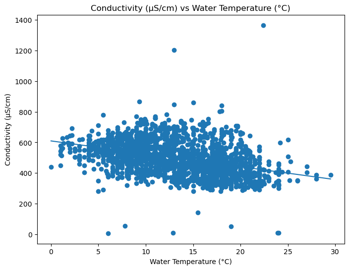

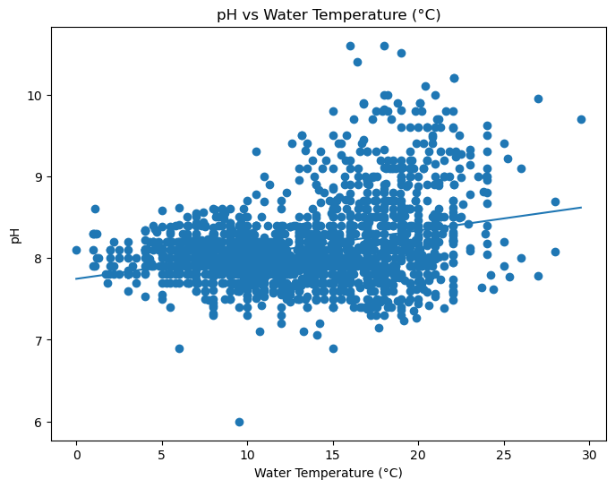

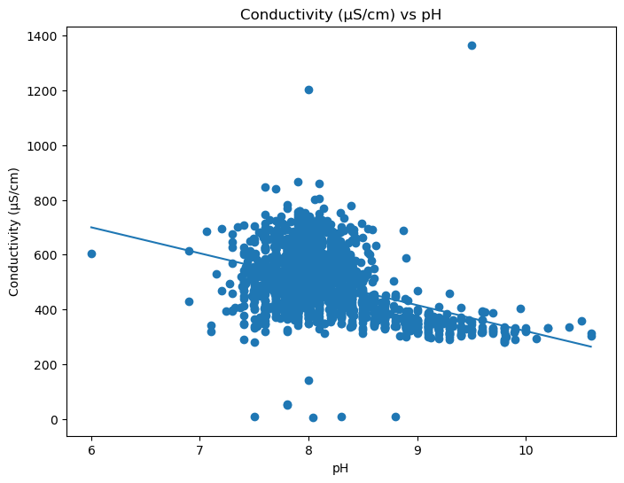

```python
import pandas as pd
import matplotlib.pyplot as plt
import numpy as np

#Ensure numeric
for col in ["Temperature", "pH", "Conductivity"]:
    df[col] = pd.to_numeric(df[col], errors="coerce")

# Drop missing values
df = df.dropna(subset=["Temperature", "pH", "Conductivity"])

def scatter_regression(x, y, xlabel, ylabel, filename):
    plt.figure(figsize=(8,6))
    plt.scatter(df[x], df[y])

    # Regression line
    m, b = np.polyfit(df[x], df[y], 1)
    x_vals = np.linspace(df[x].min(), df[x].max(), 100)
    y_vals = m * x_vals + b
    plt.plot(x_vals, y_vals)

    plt.xlabel(xlabel)
    plt.ylabel(ylabel)
    plt.title(f"{ylabel} vs {xlabel}")
    plt.savefig(filename, dpi=300, bbox_inches="tight")
    plt.show()

# 1) Conductivity vs Temperature
scatter_regression("Temperature", "Conductivity", "Water Temperature (°C)", "Conductivity (µS/cm)", "C:/Users/User/Desktop/Assignment_1/Nutrients_Analysis/reg_temp_cond.png")

# 2) pH vs Temperature
scatter_regression("Temperature", "pH", "Water Temperature (°C)", "pH", "C:/Users/User/Desktop/Assignment_1/Nutrients_Analysis/reg_temp_pH.png")

# 3) Conductivity vs pH
scatter_regression("pH", "Conductivity", "pH", "Conductivity (µS/cm)", "C:/Users/User/Desktop/Assignment_1/Nutrients_Analysis/reg_pH_cond.png")
```

## STATISTICAL INTERPRETATION

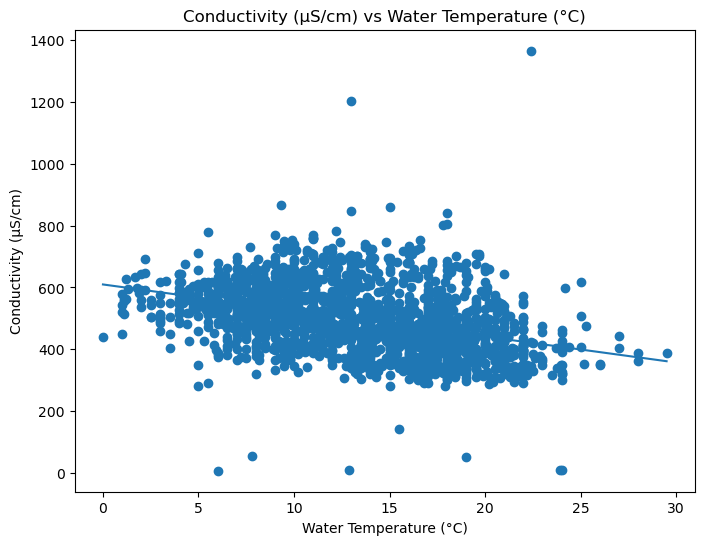

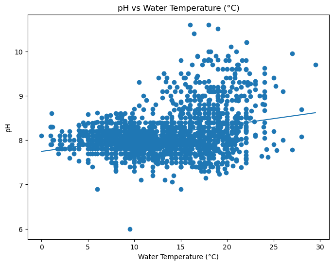

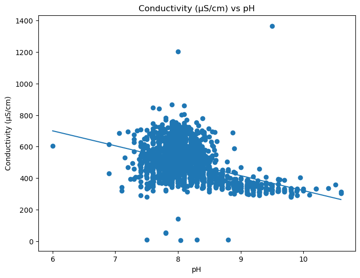

```python
import pandas as pd
import matplotlib.pyplot as plt
import numpy as np

# Ensure numeric
for col in ["Temperature", "pH", "Conductivity"]:
    df[col] = pd.to_numeric(df[col], errors="coerce")

# Drop missing values
df = df.dropna(subset=["Temperature", "pH", "Conductivity"])

def scatter_regression(x, y, xlabel, ylabel, filename):
    plt.figure(figsize=(8,6))
    plt.scatter(df[x], df[y])

    # Regression line
    m, b = np.polyfit(df[x], df[y], 1)
    x_vals = np.linspace(df[x].min(), df[x].max(), 100)
    y_vals = m * x_vals + b
    plt.plot(x_vals, y_vals)

    plt.xlabel(xlabel)
    plt.ylabel(ylabel)
    plt.title(f"{ylabel} vs {xlabel}")
    plt.savefig(filename, dpi=300, bbox_inches="tight")
    plt.show()

# 1) Conductivity vs Temperature
scatter_regression("Temperature", "Conductivity", "Water Temperature (°C)", "Conductivity (µS/cm)", "C:/Users/User/Desktop/Assignment_1/Nutrients_Analysis/Regression_temp_cond.png")

# 2) pH vs Temperature
scatter_regression("Temperature", "pH", "Water Temperature (°C)", "pH", "C:/Users/User/Desktop/Assignment_1/Nutrients_Analysis/Regression_temp_pH.png")

# 3) Conductivity vs pH
scatter_regression("pH", "Conductivity", "pH", "Conductivity (µS/cm)", "C:/Users/User/Desktop/Assignment_1/Nutrients_Analysis/Regression_pH_cond.png")
```

# Regrssion Analysis

```python
import pandas as pd
import numpy as np
from scipy.stats import pearsonr, spearmanr
import statsmodels.api as sm
```

```python
# Ensure numeric
for col in ["Temperature", "pH", "Conductivity"]:
    df[col] = pd.to_numeric(df[col], errors="coerce")

df = df.dropna(subset=["Temperature", "pH", "Conductivity"])

# Function to compute correlations
def correlations(x, y):
    pear = pearsonr(df[x], df[y])
    spear = spearmanr(df[x], df[y])
    return pear, spear

corr_results = {}

pairs = [
    ("Temperature", "Conductivity"),
    ("Temperature", "pH"),
    ("pH", "Conductivity")
]

for x, y in pairs:
    pear, spear = correlations(x, y)
    corr_results[f"{y} vs {x}"] = {
        "Pearson_r": pear[0],
        "Pearson_p": pear[1],
        "Spearman_r": spear[0],
        "Spearman_p": spear[1]
    }

# Linear regression function
def regression(x, y):
    X = sm.add_constant(df[x])
    model = sm.OLS(df[y], X).fit()
    return model.summary()

reg_temp_cond = regression("Temperature", "Conductivity")
reg_temp_pH = regression("Temperature", "pH")
reg_pH_cond = regression("pH", "Conductivity")

corr_results
```

```
{'Conductivity vs Temperature': {'Pearson_r': -0.3905851435130574,
  'Pearson_p': 2.632317293254902e-69,
  'Spearman_r': -0.4476800359229303,
  'Spearman_p': 5.528399684496011e-93},
 'pH vs Temperature': {'Pearson_r': 0.3165368663615117,
  'Pearson_p': 7.394821001706858e-45,
  'Spearman_r': 0.2281415022616015,
  'Spearman_p': 1.537835692313632e-23},
 'Conductivity vs pH': {'Pearson_r': -0.4098914218927998,
  'Pearson_p': 8.356927286577209e-77,
  'Spearman_r': -0.3337294344739789,
  'Spearman_p': 5.843173094766798e-50}}
```

| Relationship | Pearson r | p-value | Spearman r | p-value | Interpretation |
| --- | --- | --- | --- | --- | --- |
| **Conductivity vs Temperature** | **-0.39** | <0.001 | **-0.45** | <0.001 | Moderate **negative** relationship |
| **pH vs Temperature** | **+0.32** | <0.001 | **+0.23** | <0.001 | Weak **positive** relationship |
| **Conductivity vs pH** | **-0.41** | <0.001 | **-0.33** | <0.001 | Moderate **negative** relationship |

```python
!pip install ace_tools
```

```python
import pandas as pd
from scipy.stats import pearsonr, spearmanr

# Load your dataset
df = pd.read_csv("pond_data.csv")

# Ensure numeric
for col in ["Temperature", "pH", "Conductivity"]:
    df[col] = pd.to_numeric(df[col], errors="coerce")

df = df.dropna(subset=["Temperature", "pH", "Conductivity"])

# Compute correlation table
rows = []
pairs = [
    ("Temperature", "Conductivity"),
    ("Temperature", "pH"),
    ("pH", "Conductivity")
]

for x, y in pairs:
    pear_r, pear_p = pearsonr(df[x], df[y])
    spear_r, spear_p = spearmanr(df[x], df[y])
    rows.append([f"{y} vs {x}", pear_r, pear_p, spear_r, spear_p])

corr_df = pd.DataFrame(rows, columns=["Relationship", "Pearson_r", "Pearson_p", "Spearman_r", "Spearman_p"])

print(corr_df)
```

```
                  Relationship  Pearson_r     Pearson_p  Spearman_r  \
0  Conductivity vs Temperature  -0.390585  2.632317e-69   -0.447680
1            pH vs Temperature   0.316537  7.394821e-45    0.228142
2           Conductivity vs pH  -0.409891  8.356927e-77   -0.333729

     Spearman_p
0  5.528400e-93
1  1.537836e-23
2  5.843173e-50
```

## Optional Visualization for Correlation

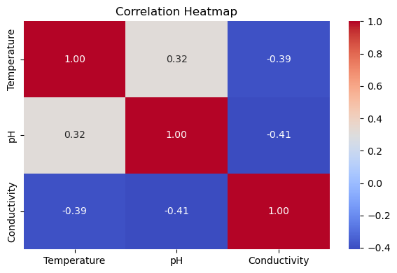

```python
import seaborn as sns
import matplotlib.pyplot as plt

corr_matrix = df[["Temperature", "pH", "Conductivity"]].corr()

plt.figure(figsize=(6,4))
sns.heatmap(corr_matrix, annot=True, cmap="coolwarm", fmt=".2f")
plt.title("Correlation Heatmap")
plt.tight_layout()
plt.savefig('C:/Users/User/Desktop/Assignment_1/Nutrients_Analysis/correlation_table.png', dpi=300, bbox_inches="tight")
plt.show()
```

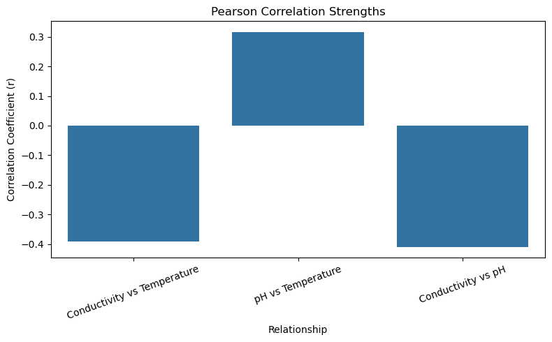

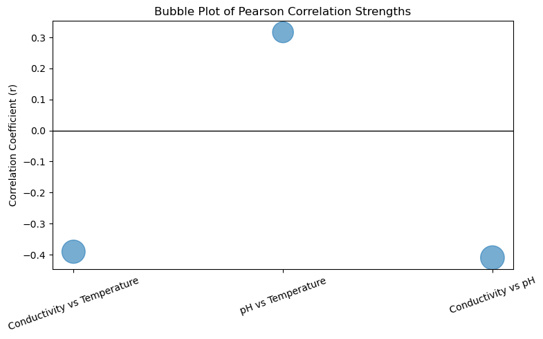

|  | Relationship | Pearson_r | Pearson_p | Spearman_r | Spearman_p |
| --- | --- | --- | --- | --- | --- |
| 0 | Conductivity vs Temperature | -0.390585 | 2.632317e-69 | -0.447680 | 5.528400e-93 |
| 1 | pH vs Temperature | 0.316537 | 7.394821e-45 | 0.228142 | 1.537836e-23 |
| 2 | Conductivity vs pH | -0.409891 | 8.356927e-77 | -0.333729 | 5.843173e-50 |

```python
# Ensure numeric
for col in ["Temperature", "pH", "Conductivity"]:
    df[col] = pd.to_numeric(df[col], errors="coerce")

df = df.dropna(subset=["Temperature", "pH", "Conductivity"])

# Compute correlation table
rows = []
pairs = [
    ("Temperature", "Conductivity"),
    ("Temperature", "pH"),
    ("pH", "Conductivity")
]

for x, y in pairs:
    pear_r, pear_p = pearsonr(df[x], df[y])
    spear_r, spear_p = spearmanr(df[x], df[y])
    rows.append([f"{y} vs {x}", pear_r, pear_p, spear_r, spear_p])

corr_df = pd.DataFrame(rows, columns=["Relationship", "Pearson_r", "Pearson_p", "Spearman_r", "Spearman_p"])

# ---- A) Bar Chart of Correlation Strengths ----
plt.figure(figsize=(8,5))
sns.barplot(data=corr_df, x="Relationship", y="Pearson_r")
plt.title("Pearson Correlation Strengths")
plt.xticks(rotation=20)
plt.ylabel("Correlation Coefficient (r)")
plt.tight_layout()
plt.savefig('C:/Users/User/Desktop/Assignment_1/Nutrients_Analysis/correlation_strengths_bar.png', dpi=300, bbox_inches="tight")
plt.show()

# ---- B) Bubble Plot ----
bubble_df = corr_df.copy()
bubble_df["Size"] = abs(bubble_df["Pearson_r"]) * 1500

plt.figure(figsize=(8,5))
plt.scatter(bubble_df["Relationship"], bubble_df["Pearson_r"], s=bubble_df["Size"], alpha=0.6)
plt.axhline(0, color='black', linewidth=1)
plt.title("Bubble Plot of Pearson Correlation Strengths")
plt.ylabel("Correlation Coefficient (r)")
plt.xticks(rotation=20)
plt.tight_layout()
plt.savefig('C:/Users/User/Desktop/Assignment_1/Nutrients_Analysis/correlation_bubble_plot.png', dpi=300, bbox_inches="tight")
plt.show()

corr_df
```

```python
df.columns
```

```
Index(['Sampling_Date', 'Ponds', 'Conductivity', 'Temperature', 'pH',
       'Month_Name', 'Year', 'Month', 'Season'],
      dtype='object')
```

```python
df['Ponds'].unique()
```

```
array(['Central_Arm', 'Eastern_Arm', 'Western_Arm_Spring_Inflow',
       'Western_Arm'], dtype=object)
```

#### LETS CHECK THE RELATIONSHIP BTWEEN THE Western_Arm_Spring_Inflow and Western_Arm

```python
import pandas as pd
import numpy as np
import matplotlib.pyplot as plt
from scipy.stats import pearsonr
import statsmodels.api as sm
```

```python
# Ensure numeric
for col in ["Temperature", "pH", "Conductivity"]:
    df[col] = pd.to_numeric(df[col], errors="coerce")
```

### Filter two sites The Western Arm Spring inflow and Western Arm

```python
inflow = df[df["Ponds"] == "Western_Arm_Spring_Inflow"]
arm = df[df["Ponds"] == "Western_Arm"]
```

#### To compare fairly: compute monthly means for both

```python
inflow_month = inflow.groupby(["Year","Month"], as_index=False).mean(numeric_only=True)
arm_month = arm.groupby(["Year","Month"], as_index=False).mean(numeric_only=True)
```

#### Merge on Year+Month to align time

```python
merged = pd.merge(inflow_month, arm_month, on=["Year","Month"], suffixes=("_Inflow","_Arm"))
```

```python
merged.head()
```

|  | Year | Month | Conductivity_Inflow | Temperature_Inflow | pH_Inflow | Conductivity_Arm | Temperature_Arm | pH_Arm |
| --- | --- | --- | --- | --- | --- | --- | --- | --- |
| 0 | 1980 | 11 | 524.0 | 5.5 | 7.9 | 482.0 | 6.5 | 8.0 |
| 1 | 1981 | 1 | 619.0 | 5.5 | 8.0 | 589.0 | 4.5 | 8.1 |
| 2 | 1981 | 2 | 613.0 | 6.5 | 7.8 | 590.0 | 6.5 | 8.1 |
| 3 | 1981 | 3 | 504.0 | 9.5 | 7.4 | 605.0 | 9.5 | 6.0 |
| 4 | 1981 | 4 | 539.0 | 8.0 | 8.0 | 482.0 | 8.0 | 8.2 |

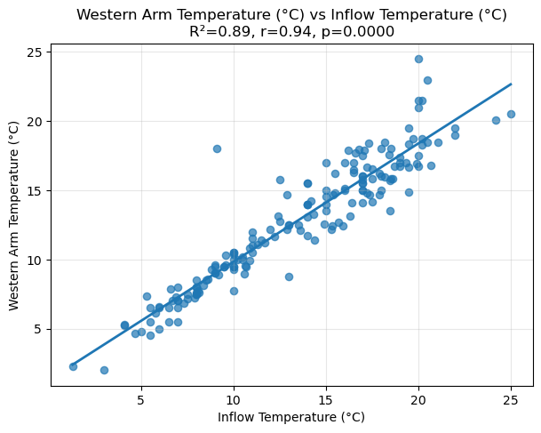

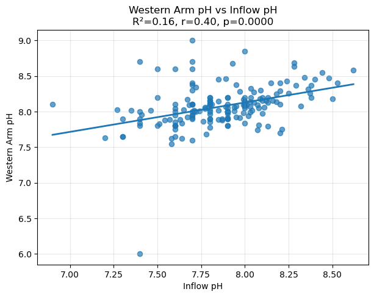

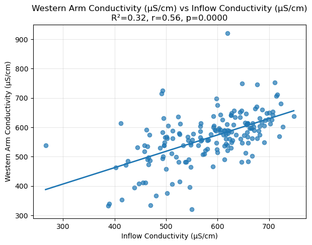

```
{'Temperature': (0.8857495241124811,
  0.9411426693719083,
  2.3356393532051863e-84,
  0.8553392295671796,
  1.276789262365556),
 'pH': (0.15647784937739107,
  0.39557281172672987,
  5.0543194629197024e-08,
  0.4135383140575044,
  4.81940064991174),
 'Conductivity': (0.31921903779265215,
  0.5649947236856747,
  2.575243842299429e-16,
  0.5575826541692516,
  239.3742696615921)}
```

```python
# Function to do regression and plot
def regress_plot(x, y, xlabel, ylabel, filename):
    sub = merged[[x,y]].dropna()
    X = sm.add_constant(sub[x])
    model = sm.OLS(sub[y], X).fit()
    slope = model.params[x]
    intercept = model.params["const"]
    r2 = model.rsquared

    # Pearson r
    r, p = pearsonr(sub[x], sub[y])

    # Plot
    plt.figure(figsize=(7,5))
    plt.scatter(sub[x], sub[y], s=35, alpha=0.7)
    xs = np.linspace(sub[x].min(), sub[x].max(), 100)
    plt.plot(xs, slope*xs + intercept, linewidth=2)
    plt.xlabel(xlabel)
    plt.ylabel(ylabel)
    plt.title(f"{ylabel} vs {xlabel}\nR²={r2:.2f}, r={r:.2f}, p={p:.4f}")
    plt.grid(True, alpha=0.3)
    plt.savefig(filename, dpi=300, bbox_inches="tight")
    plt.show()

    return r2, r, p, slope, intercept

results = {}

results["Temperature"] = regress_plot(
    "Temperature_Inflow","Temperature_Arm",
    "Inflow Temperature (°C)","Western Arm Temperature (°C)",
    "C:/Users/User/Desktop/Assignment_1/Nutrients_Analysis/reg_inflow_arm_temperature.png"
)

results["pH"] = regress_plot(
    "pH_Inflow","pH_Arm",
    "Inflow pH","Western Arm pH",
    "C:/Users/User/Desktop/Assignment_1/Nutrients_Analysis/reg_inflow_arm_pH.png"
)

results["Conductivity"] = regress_plot(
    "Conductivity_Inflow","Conductivity_Arm",
    "Inflow Conductivity (µS/cm)","Western Arm Conductivity (µS/cm)",
    "C:/Users/User/Desktop/Assignment_1/Nutrients_Analysis/reg_inflow_arm_conductivity.png"
)

results
```

[output not shown]

```python
import pandas as pd
import numpy as np
from scipy.stats import mannwhitneyu
from statsmodels.stats.multitest import multipletests

for col in ["Temperature", "pH", "Conductivity"]:
    df[col] = pd.to_numeric(df[col], errors="coerce")

# Focus on Western Arm vs Inflow only
pairs = [("Western_Arm_Spring_Inflow", "Western_Arm")]
variables = ["Temperature", "pH", "Conductivity"]

results = []

for var in variables:
    g1 = df[df["Ponds"] == "Western_Arm_Spring_Inflow"][var].dropna()
    g2 = df[df["Ponds"] == "Western_Arm"][var].dropna()
    stat, p = mannwhitneyu(g1, g2, alternative="two-sided")
    results.append([var, stat, p])

mw_df = pd.DataFrame(results, columns=["Variable","Statistic Mann-Whitney U","p_value"])

# Holm correction
mw_df["p_value_corrected"] = multipletests(mw_df["p_value"], method="holm")[1]
mw_df
```

|  | Variable | Statistic Mann-Whitney U | p_value | p_value_corrected |
| --- | --- | --- | --- | --- |
| 0 | Temperature | 46843.5 | 4.992541e-01 | 9.985081e-01 |
| 1 | pH | 27785.0 | 6.058847e-16 | 1.817654e-15 |
| 2 | Conductivity | 46023.5 | 7.649590e-01 | 9.985081e-01 |

| Variable | Mann-Whitney U | p-value | Holm-Corrected p | Interpretation |
| --- | --- | --- | --- | --- |
| **Temperature** | 46843.5 | 4.992541e-01 | 9.985081e-01 | ❌ No significant difference |
| **pH** | 27785.0 | 6.058847e-16 | 1.817654e-15 | ✅ **Highly significant difference** |
| **Conductivity** | 46023.5 | 7.649590e-01 | 9.985081e-01 | ❌ No significant difference |

## MACHINE LEARNING RANDOM FOREST ANALYSIS

## Lets Load our Libraries

```python
import pandas as pd
import numpy as np
import matplotlib.pyplot as plt
import plotly.express as px
from sklearn.model_selection import train_test_split
from sklearn.ensemble import RandomForestRegressor
from sklearn.metrics import r2_score, mean_absolute_error, mean_squared_error
```

```python
df.head()
```

|  | Sampling_Date | Ponds | Conductivity | Temperature | pH | Month_Name | Year | Month | Season |
| --- | --- | --- | --- | --- | --- | --- | --- | --- | --- |
| 0 | 7/26/1977 | Central_Arm | 360.0 | 16.0 | 7.9 | July | 1977 | 7 | Summer |
| 1 | 7/26/1977 | Central_Arm | 300.0 | 16.5 | 8.9 | July | 1977 | 7 | Summer |
| 2 | 7/26/1977 | Eastern_Arm | 380.0 | 18.0 | 8.4 | July | 1977 | 7 | Summer |
| 3 | 7/26/1977 | Eastern_Arm | 390.0 | 18.5 | 8.2 | July | 1977 | 7 | Summer |
| 4 | 7/26/1977 | Western_Arm_Spring_Inflow | 430.0 | 15.0 | 6.9 | July | 1977 | 7 | Summer |

```python
df.columns
```

```
Index(['Sampling_Date', 'Ponds', 'Conductivity', 'Temperature', 'pH',
       'Month_Name', 'Year', 'Month', 'Season'],
      dtype='object')
```

## Define the parameters our target is pH

```python
target = "pH"

numeric_features = ["Conductivity", "Temperature"]  # adjust as needed
categorical_features = ["Season", "Month_Name", "Ponds"]            # your list
```

```python
dfm = df[[target] + numeric_features + categorical_features].copy()

dfm = dfm.replace([np.inf, -np.inf], np.nan)

# (Optional) make sure numeric columns are numeric
dfm[numeric_features] = dfm[numeric_features].apply(pd.to_numeric, errors="coerce")

# Drop rows missing the target (keep predictors flexible)
dfm = dfm.dropna(subset=[target])

dfm.head()
```

|  | pH | Conductivity | Temperature | Season | Month_Name | Ponds |
| --- | --- | --- | --- | --- | --- | --- |
| 0 | 7.9 | 360.0 | 16.0 | Summer | July | Central_Arm |
| 1 | 8.9 | 300.0 | 16.5 | Summer | July | Central_Arm |
| 2 | 8.4 | 380.0 | 18.0 | Summer | July | Eastern_Arm |
| 3 | 8.2 | 390.0 | 18.5 | Summer | July | Eastern_Arm |
| 4 | 6.9 | 430.0 | 15.0 | Summer | July | Western_Arm_Spring_Inflow |

```python
X_num = dfm[numeric_features]

X_cat = dfm[categorical_features].astype("category")

X = pd.concat([X_num, X_cat], axis=1)

X_encoded = pd.get_dummies(X, columns=categorical_features, drop_first=True)

y = dfm[target]
```

## SPLIT TRAINING AND TESTING DATA

```python
# Drop rows with any remaining NaNs in X or y to avoid misalignment
aligned = pd.concat([y, X_encoded], axis=1).dropna()

y_aligned = aligned[target]
X_aligned = aligned.drop(columns=[target])

X_train, X_test, y_train, y_test = train_test_split(
    X_aligned, y_aligned, test_size=0.2, random_state=42
)

X_train.shape, X_test.shape
```

```
((1498, 19), (375, 19))
```

### TRAIN THE RANDOM FOREST ALGORITHM

```python
rf = RandomForestRegressor(n_estimators=200, random_state=42)
rf.fit(X_train, y_train)
```

```
RandomForestRegressor(n_estimators=200, random_state=42)
```

## ACCURACY ASSESMENT

```python
y_pred = rf.predict(X_test)

r2  = r2_score(y_test, y_pred)
mae = mean_absolute_error(y_test, y_pred)
rmse = mean_squared_error(y_test, y_pred, squared=False)

print(f"R²  = {r2:.3f}")
print(f"MAE = {mae:.3f}")
print(f"RMSE= {rmse:.3f}")
```

```
R²  = 0.494
MAE = 0.247
RMSE= 0.361
```

### ACTUAL VS PREDICTED

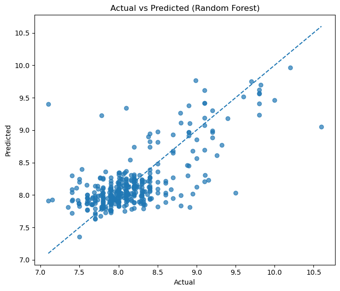

```python
plt.figure(figsize=(7,6))
plt.scatter(y_test, y_pred, alpha=0.7)
plt.plot([y_test.min(), y_test.max()], [y_test.min(), y_test.max()], linestyle="--")
plt.title("Actual vs Predicted (Random Forest)")
plt.xlabel("Actual")
plt.ylabel("Predicted")
plt.tight_layout()
plt.show()
```

### RESIDUALS

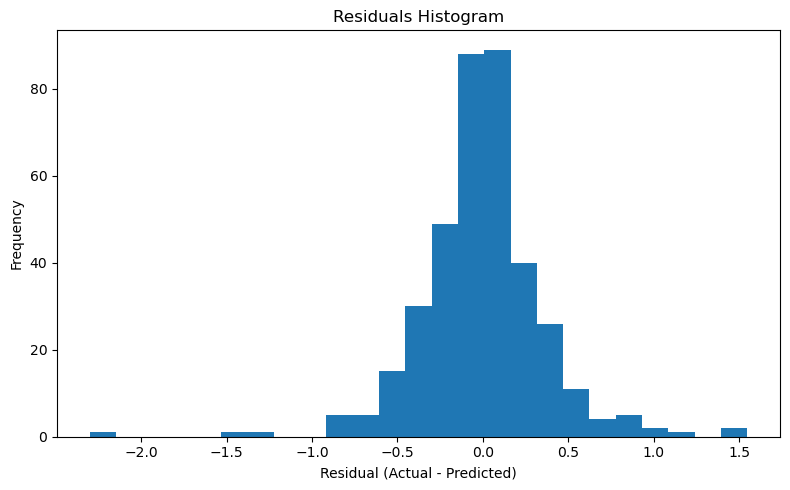

```python
residuals = y_test - y_pred

plt.figure(figsize=(8,5))
plt.hist(residuals, bins=25)
plt.title("Residuals Histogram")
plt.xlabel("Residual (Actual - Predicted)")
plt.ylabel("Frequency")
plt.tight_layout()
plt.show()
```

### FEATURE IMPORTANCES THE MOST IMPORTANT PREDICTORS

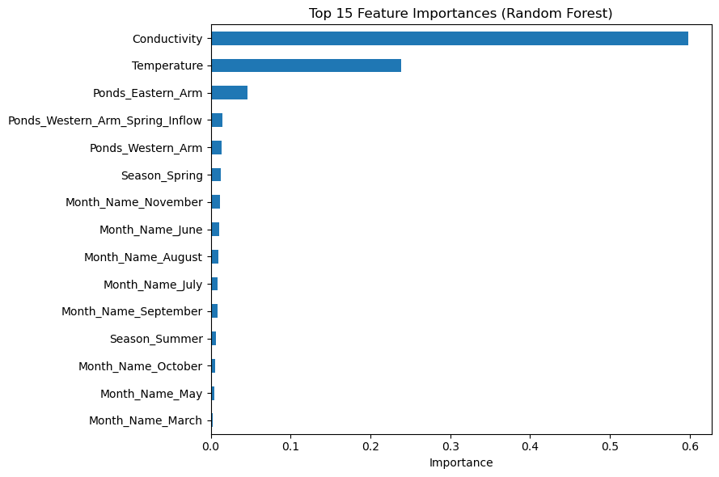

```python
importances = pd.Series(rf.feature_importances_, index=X_aligned.columns)
imp_sorted = importances.sort_values(ascending=True)

top = imp_sorted.tail(15)

plt.figure(figsize=(9,6))
top.plot(kind="barh")
plt.title("Top 15 Feature Importances (Random Forest)")
plt.xlabel("Importance")
plt.tight_layout()
plt.show()
```

#### PARAMETER TUNING TO IMPROVE THE PERFOMANCE OF THE MODEL

```python
from sklearn.model_selection import GridSearchCV
from sklearn.ensemble import RandomForestRegressor
```

```python
param_grid = {
    "n_estimators": [100, 200, 300],
    "max_depth": [None, 5, 10, 20],
    "min_samples_split": [2, 5, 10],
    "min_samples_leaf": [1, 2, 4],
    "max_features": ["auto", "sqrt", "log2"]
}
```

```python
rf_base = RandomForestRegressor(random_state=42)

grid_search = GridSearchCV(
    estimator=rf_base,
    param_grid=param_grid,
    cv=5,              # 5-fold cross-validation
    n_jobs=-1,         # use all CPU cores
    scoring="r2",      # optimize for R²
    verbose=2
)
```